# Risk Factor Analysis

## Outcome Variable

**Outcome Variable:** sstunted

## Predictor Variables

**Intervention Variable:** exclfeed3

**Adjustment Set:**

- arm
- sex
- W_mage
- meducyrs
- feducyrs
- hhwealth_quart
- hfoodsec
- W_mhtcm
- vagbrth
- W_gagebrth
- W_birthwt
- W_birthlen
- W_nrooms
- W_nchldlt5
- month
- brthmon
- W_parity
- impfloor
- impsan
- safeh20
- delta_W_mage
- delta_meducyrs
- delta_feducyrs
- delta_hhwealth_quart
- delta_hfoodsec
- delta_W_mhtcm
- delta_vagbrth
- delta_W_gagebrth
- delta_W_birthwt
- delta_W_birthlen
- delta_W_nrooms
- delta_W_nchldlt5
- delta_month
- delta_brthmon
- delta_W_parity
- delta_impfloor
- delta_impsan
- delta_safeh20

## Stratifying Variables

The analysis was stratified on these variable(s):

- agecat
- studyid
- country

## Data Summary

| agecat | studyid | country | exclfeed3 | sstunted | n_cell | n |
| --- | --- | --- | --- | --- | --- | --- |
| Birth | ki0047075b-MAL-ED | BANGLADESH | 0 | 0 | 64 | 240 |
| Birth | ki0047075b-MAL-ED | BANGLADESH | 0 | 1 | 3 | 240 |
| Birth | ki0047075b-MAL-ED | BANGLADESH | 1 | 0 | 169 | 240 |
| Birth | ki0047075b-MAL-ED | BANGLADESH | 1 | 1 | 4 | 240 |
| Birth | ki0047075b-MAL-ED | BRAZIL | 0 | 0 | 112 | 185 |
| Birth | ki0047075b-MAL-ED | BRAZIL | 0 | 1 | 6 | 185 |
| Birth | ki0047075b-MAL-ED | BRAZIL | 1 | 0 | 65 | 185 |
| Birth | ki0047075b-MAL-ED | BRAZIL | 1 | 1 | 2 | 185 |
| Birth | ki0047075b-MAL-ED | INDIA | 0 | 0 | 71 | 196 |
| Birth | ki0047075b-MAL-ED | INDIA | 0 | 1 | 2 | 196 |
| Birth | ki0047075b-MAL-ED | INDIA | 1 | 0 | 118 | 196 |
| Birth | ki0047075b-MAL-ED | INDIA | 1 | 1 | 5 | 196 |
| Birth | ki0047075b-MAL-ED | NEPAL | 0 | 0 | 106 | 171 |
| Birth | ki0047075b-MAL-ED | NEPAL | 0 | 1 | 4 | 171 |
| Birth | ki0047075b-MAL-ED | NEPAL | 1 | 0 | 59 | 171 |
| Birth | ki0047075b-MAL-ED | NEPAL | 1 | 1 | 2 | 171 |
| Birth | ki0047075b-MAL-ED | PERU | 0 | 0 | 203 | 272 |
| Birth | ki0047075b-MAL-ED | PERU | 0 | 1 | 2 | 272 |
| Birth | ki0047075b-MAL-ED | PERU | 1 | 0 | 63 | 272 |
| Birth | ki0047075b-MAL-ED | PERU | 1 | 1 | 4 | 272 |
| Birth | ki0047075b-MAL-ED | SOUTH AFRICA | 0 | 0 | 200 | 233 |
| Birth | ki0047075b-MAL-ED | SOUTH AFRICA | 0 | 1 | 1 | 233 |
| Birth | ki0047075b-MAL-ED | SOUTH AFRICA | 1 | 0 | 32 | 233 |
| Birth | ki0047075b-MAL-ED | SOUTH AFRICA | 1 | 1 | 0 | 233 |
| Birth | ki0047075b-MAL-ED | TANZANIA, UNITED REPUBLIC OF | 0 | 0 | 76 | 119 |
| Birth | ki0047075b-MAL-ED | TANZANIA, UNITED REPUBLIC OF | 0 | 1 | 4 | 119 |
| Birth | ki0047075b-MAL-ED | TANZANIA, UNITED REPUBLIC OF | 1 | 0 | 37 | 119 |
| Birth | ki0047075b-MAL-ED | TANZANIA, UNITED REPUBLIC OF | 1 | 1 | 2 | 119 |
| Birth | ki1000108-CMC-V-BCS-2002 | INDIA | 0 | 0 | 0 | 4 |
| Birth | ki1000108-CMC-V-BCS-2002 | INDIA | 0 | 1 | 0 | 4 |

[output cut: 146 more lines]

The following strata were considered:

- agecat: 24 months, studyid: ki0047075b-MAL-ED, country: BANGLADESH
- agecat: 24 months, studyid: ki0047075b-MAL-ED, country: BRAZIL
- agecat: 24 months, studyid: ki0047075b-MAL-ED, country: INDIA
- agecat: 24 months, studyid: ki0047075b-MAL-ED, country: NEPAL
- agecat: 24 months, studyid: ki0047075b-MAL-ED, country: PERU
- agecat: 24 months, studyid: ki0047075b-MAL-ED, country: SOUTH AFRICA
- agecat: 24 months, studyid: ki0047075b-MAL-ED, country: TANZANIA, UNITED REPUBLIC OF
- agecat: 24 months, studyid: ki1000108-CMC-V-BCS-2002, country: INDIA
- agecat: 24 months, studyid: ki1000108-IRC, country: INDIA
- agecat: 24 months, studyid: ki1017093b-PROVIDE, country: BANGLADESH
- agecat: 24 months, studyid: ki1101329-Keneba, country: GAMBIA
- agecat: 24 months, studyid: ki1113344-GMS-Nepal, country: NEPAL
- agecat: 24 months, studyid: kiGH5241-JiVitA-3, country: BANGLADESH
- agecat: 24 months, studyid: kiGH5241-JiVitA-4, country: BANGLADESH
- agecat: 6 months, studyid: ki0047075b-MAL-ED, country: BANGLADESH
- agecat: 6 months, studyid: ki0047075b-MAL-ED, country: BRAZIL
- agecat: 6 months, studyid: ki0047075b-MAL-ED, country: INDIA
- agecat: 6 months, studyid: ki0047075b-MAL-ED, country: NEPAL
- agecat: 6 months, studyid: ki0047075b-MAL-ED, country: PERU
- agecat: 6 months, studyid: ki0047075b-MAL-ED, country: SOUTH AFRICA
- agecat: 6 months, studyid: ki0047075b-MAL-ED, country: TANZANIA, UNITED REPUBLIC OF
- agecat: 6 months, studyid: ki1000108-CMC-V-BCS-2002, country: INDIA
- agecat: 6 months, studyid: ki1000108-IRC, country: INDIA
- agecat: 6 months, studyid: ki1000109-EE, country: PAKISTAN
- agecat: 6 months, studyid: ki1000304b-SAS-CompFeed, country: INDIA
- agecat: 6 months, studyid: ki1017093b-PROVIDE, country: BANGLADESH
- agecat: 6 months, studyid: ki1101329-Keneba, country: GAMBIA
- agecat: 6 months, studyid: ki1113344-GMS-Nepal, country: NEPAL
- agecat: 6 months, studyid: kiGH5241-JiVitA-3, country: BANGLADESH
- agecat: 6 months, studyid: kiGH5241-JiVitA-4, country: BANGLADESH
- agecat: Birth, studyid: ki0047075b-MAL-ED, country: BANGLADESH
- agecat: Birth, studyid: ki0047075b-MAL-ED, country: BRAZIL
- agecat: Birth, studyid: ki0047075b-MAL-ED, country: INDIA
- agecat: Birth, studyid: ki0047075b-MAL-ED, country: NEPAL
- agecat: Birth, studyid: ki0047075b-MAL-ED, country: PERU
- agecat: Birth, studyid: ki0047075b-MAL-ED, country: SOUTH AFRICA
- agecat: Birth, studyid: ki0047075b-MAL-ED, country: TANZANIA, UNITED REPUBLIC OF
- agecat: Birth, studyid: ki1000108-CMC-V-BCS-2002, country: INDIA
- agecat: Birth, studyid: ki1000108-IRC, country: INDIA
- agecat: Birth, studyid: ki1000109-EE, country: PAKISTAN
- agecat: Birth, studyid: ki1000304b-SAS-CompFeed, country: INDIA
- agecat: Birth, studyid: ki1101329-Keneba, country: GAMBIA
- agecat: Birth, studyid: kiGH5241-JiVitA-3, country: BANGLADESH
- agecat: Birth, studyid: kiGH5241-JiVitA-4, country: BANGLADESH

### Dropped Strata

Some strata were dropped due to rare outcomes:

- agecat: Birth, studyid: ki0047075b-MAL-ED, country: BANGLADESH
- agecat: Birth, studyid: ki0047075b-MAL-ED, country: BRAZIL
- agecat: Birth, studyid: ki0047075b-MAL-ED, country: INDIA
- agecat: Birth, studyid: ki0047075b-MAL-ED, country: NEPAL
- agecat: Birth, studyid: ki0047075b-MAL-ED, country: PERU
- agecat: Birth, studyid: ki0047075b-MAL-ED, country: SOUTH AFRICA
- agecat: Birth, studyid: ki0047075b-MAL-ED, country: TANZANIA, UNITED REPUBLIC OF
- agecat: Birth, studyid: ki1000108-CMC-V-BCS-2002, country: INDIA
- agecat: Birth, studyid: ki1000108-IRC, country: INDIA
- agecat: Birth, studyid: ki1000109-EE, country: PAKISTAN
- agecat: Birth, studyid: ki1000304b-SAS-CompFeed, country: INDIA
- agecat: Birth, studyid: ki1101329-Keneba, country: GAMBIA
- agecat: Birth, studyid: kiGH5241-JiVitA-4, country: BANGLADESH
- agecat: 6 months, studyid: ki0047075b-MAL-ED, country: BANGLADESH
- agecat: 6 months, studyid: ki0047075b-MAL-ED, country: BRAZIL
- agecat: 6 months, studyid: ki0047075b-MAL-ED, country: INDIA
- agecat: 6 months, studyid: ki0047075b-MAL-ED, country: NEPAL
- agecat: 6 months, studyid: ki0047075b-MAL-ED, country: PERU
- agecat: 6 months, studyid: ki0047075b-MAL-ED, country: SOUTH AFRICA
- agecat: 6 months, studyid: ki1000108-CMC-V-BCS-2002, country: INDIA
- agecat: 6 months, studyid: ki1000108-IRC, country: INDIA
- agecat: 6 months, studyid: ki1000304b-SAS-CompFeed, country: INDIA
- agecat: 6 months, studyid: kiGH5241-JiVitA-4, country: BANGLADESH
- agecat: 24 months, studyid: ki0047075b-MAL-ED, country: BRAZIL
- agecat: 24 months, studyid: ki0047075b-MAL-ED, country: NEPAL
- agecat: 24 months, studyid: ki0047075b-MAL-ED, country: SOUTH AFRICA
- agecat: 24 months, studyid: ki1000108-CMC-V-BCS-2002, country: INDIA
- agecat: 24 months, studyid: ki1000108-IRC, country: INDIA
- agecat: 24 months, studyid: kiGH5241-JiVitA-4, country: BANGLADESH

## Methods Detail

We’re interested in the causal parameters $E[Y_a]$ for all values of $a \in \mathcal{A}$. These parameters represent the mean outcome if, possibly contrary to fact, we intervened to set all units to have $A=a$. Under the randomization and positivity assumptions, these are identified by the statistical parameters $\psi_a=E_W[E_{Y|A,W}(Y|A=a,W)]$. In addition, we’re interested in the mean of $Y$, $E[Y]$ under no intervention (the observed mean). We will estimate these parameters by using SuperLearner to fit the relevant likelihood factors – $E_{Y|A,W}(Y|A=a,W)$ and $p(A=a|W)$, and then updating our likelihood fit using a joint TMLE.

For unadjusted analyses ($W=\{\}$), initial likelihoods were estimated using Lrnr_glm to estimate the simple $E(Y|A)$ and Lrnr_mean to estimate $p(A)$. For adjusted analyses, a small library containing Lrnr_glmnet, Lrnr_xgboost, and Lrnr_mean was used.

Having estimated these parameters, we will then use the delta method to estimate relative risks and attributable risks relative to a prespecified baseline level of $A$.

# Results Detail

## Results Plots

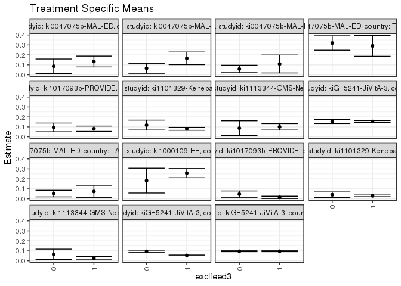

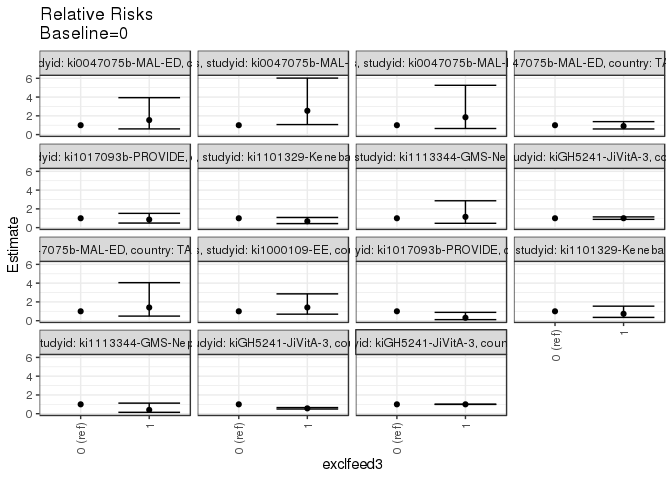

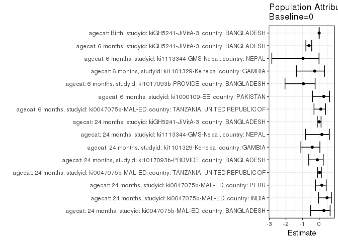

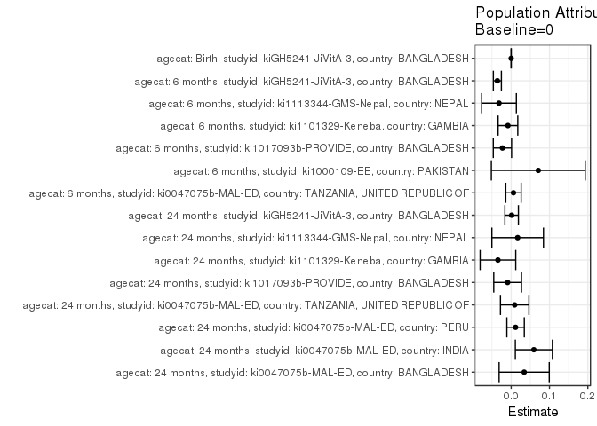

## Results Table

### Parameter: TSM

| agecat | studyid | country | intervention_level | baseline_level | estimate | ci_lower | ci_upper |
| --- | --- | --- | --- | --- | --- | --- | --- |
| Birth | kiGH5241-JiVitA-3 | BANGLADESH | 0 | NA | 0.0959551 | 0.0913802 | 0.1005300 |
| Birth | kiGH5241-JiVitA-3 | BANGLADESH | 1 | NA | 0.0959816 | 0.0914067 | 0.1005566 |
| 6 months | ki0047075b-MAL-ED | TANZANIA, UNITED REPUBLIC OF | 0 | NA | 0.0523256 | 0.0189770 | 0.0856741 |
| 6 months | ki0047075b-MAL-ED | TANZANIA, UNITED REPUBLIC OF | 1 | NA | 0.0735294 | 0.0113643 | 0.1356945 |
| 6 months | ki1000109-EE | PAKISTAN | 0 | NA | 0.1826140 | 0.0578357 | 0.3073923 |
| 6 months | ki1000109-EE | PAKISTAN | 1 | NA | 0.2574455 | 0.2113916 | 0.3034995 |
| 6 months | ki1017093b-PROVIDE | BANGLADESH | 0 | NA | 0.0467836 | 0.0151051 | 0.0784622 |
| 6 months | ki1017093b-PROVIDE | BANGLADESH | 1 | NA | 0.0145631 | 0.0029856 | 0.0261406 |
| 6 months | ki1101329-Keneba | GAMBIA | 0 | NA | 0.0405366 | 0.0125699 | 0.0685032 |
| 6 months | ki1101329-Keneba | GAMBIA | 1 | NA | 0.0297835 | 0.0212945 | 0.0382725 |
| 6 months | ki1113344-GMS-Nepal | NEPAL | 0 | NA | 0.0644759 | 0.0118728 | 0.1170790 |
| 6 months | ki1113344-GMS-Nepal | NEPAL | 1 | NA | 0.0263468 | 0.0102134 | 0.0424801 |
| 6 months | kiGH5241-JiVitA-3 | BANGLADESH | 0 | NA | 0.0947099 | 0.0828459 | 0.1065739 |
| 6 months | kiGH5241-JiVitA-3 | BANGLADESH | 1 | NA | 0.0540610 | 0.0504525 | 0.0576694 |
| 24 months | ki0047075b-MAL-ED | BANGLADESH | 0 | NA | 0.0862069 | 0.0138007 | 0.1586131 |
| 24 months | ki0047075b-MAL-ED | BANGLADESH | 1 | NA | 0.1333333 | 0.0788022 | 0.1878644 |
| 24 months | ki0047075b-MAL-ED | INDIA | 0 | NA | 0.0652174 | 0.0146514 | 0.1157834 |
| 24 months | ki0047075b-MAL-ED | INDIA | 1 | NA | 0.1654135 | 0.1021271 | 0.2287000 |
| 24 months | ki0047075b-MAL-ED | PERU | 0 | NA | 0.0588235 | 0.0214463 | 0.0962008 |
| 24 months | ki0047075b-MAL-ED | PERU | 1 | NA | 0.1086957 | 0.0185215 | 0.1988698 |
| 24 months | ki0047075b-MAL-ED | TANZANIA, UNITED REPUBLIC OF | 0 | NA | 0.3193743 | 0.2471848 | 0.3915638 |
| 24 months | ki0047075b-MAL-ED | TANZANIA, UNITED REPUBLIC OF | 1 | NA | 0.2902454 | 0.1860729 | 0.3944178 |
| 24 months | ki1017093b-PROVIDE | BANGLADESH | 0 | NA | 0.0941437 | 0.0502252 | 0.1380621 |
| 24 months | ki1017093b-PROVIDE | BANGLADESH | 1 | NA | 0.0810784 | 0.0545390 | 0.1076178 |
| 24 months | ki1101329-Keneba | GAMBIA | 0 | NA | 0.1176083 | 0.0678144 | 0.1674022 |
| 24 months | ki1101329-Keneba | GAMBIA | 1 | NA | 0.0803666 | 0.0654367 | 0.0952965 |
| 24 months | ki1113344-GMS-Nepal | NEPAL | 0 | NA | 0.0869700 | 0.0129398 | 0.1610002 |
| 24 months | ki1113344-GMS-Nepal | NEPAL | 1 | NA | 0.1001573 | 0.0678926 | 0.1324219 |
| 24 months | kiGH5241-JiVitA-3 | BANGLADESH | 0 | NA | 0.1533864 | 0.1330518 | 0.1737210 |
| 24 months | kiGH5241-JiVitA-3 | BANGLADESH | 1 | NA | 0.1540595 | 0.1450580 | 0.1630610 |

### Parameter: E(Y)

| agecat | studyid | country | intervention_level | baseline_level | estimate | ci_lower | ci_upper |
| --- | --- | --- | --- | --- | --- | --- | --- |
| Birth | kiGH5241-JiVitA-3 | BANGLADESH | NA | NA | 0.0959914 | 0.0914158 | 0.1005671 |
| 6 months | ki0047075b-MAL-ED | TANZANIA, UNITED REPUBLIC OF | NA | NA | 0.0583333 | 0.0286197 | 0.0880470 |
| 6 months | ki1000109-EE | PAKISTAN | NA | NA | 0.2533693 | 0.2090516 | 0.2976870 |
| 6 months | ki1017093b-PROVIDE | BANGLADESH | NA | NA | 0.0240137 | 0.0115761 | 0.0364514 |
| 6 months | ki1101329-Keneba | GAMBIA | NA | NA | 0.0321470 | 0.0238614 | 0.0404325 |
| 6 months | ki1113344-GMS-Nepal | NEPAL | NA | NA | 0.0327511 | 0.0164329 | 0.0490693 |
| 6 months | kiGH5241-JiVitA-3 | BANGLADESH | NA | NA | 0.0587188 | 0.0549206 | 0.0625169 |
| 24 months | ki0047075b-MAL-ED | BANGLADESH | NA | NA | 0.1201923 | 0.0758932 | 0.1644914 |
| 24 months | ki0047075b-MAL-ED | INDIA | NA | NA | 0.1244444 | 0.0812176 | 0.1676713 |
| 24 months | ki0047075b-MAL-ED | PERU | NA | NA | 0.0703518 | 0.0347303 | 0.1059733 |
| 24 months | ki0047075b-MAL-ED | TANZANIA, UNITED REPUBLIC OF | NA | NA | 0.3285714 | 0.2648934 | 0.3922495 |
| 24 months | ki1017093b-PROVIDE | BANGLADESH | NA | NA | 0.0849220 | 0.0621566 | 0.1076874 |
| 24 months | ki1101329-Keneba | GAMBIA | NA | NA | 0.0830986 | 0.0687366 | 0.0974606 |
| 24 months | ki1113344-GMS-Nepal | NEPAL | NA | NA | 0.1039604 | 0.0741620 | 0.1337588 |
| 24 months | kiGH5241-JiVitA-3 | BANGLADESH | NA | NA | 0.1546577 | 0.1455620 | 0.1637534 |

### Parameter: RR

| agecat | studyid | country | intervention_level | baseline_level | estimate | ci_lower | ci_upper |
| --- | --- | --- | --- | --- | --- | --- | --- |
| Birth | kiGH5241-JiVitA-3 | BANGLADESH | 0 | 0 | 1.0000000 | 1.0000000 | 1.0000000 |
| Birth | kiGH5241-JiVitA-3 | BANGLADESH | 1 | 0 | 1.0002767 | 1.0001265 | 1.0004268 |
| 6 months | ki0047075b-MAL-ED | TANZANIA, UNITED REPUBLIC OF | 0 | 0 | 1.0000000 | 1.0000000 | 1.0000000 |
| 6 months | ki0047075b-MAL-ED | TANZANIA, UNITED REPUBLIC OF | 1 | 0 | 1.4052288 | 0.4874555 | 4.0509706 |
| 6 months | ki1000109-EE | PAKISTAN | 0 | 0 | 1.0000000 | 1.0000000 | 1.0000000 |
| 6 months | ki1000109-EE | PAKISTAN | 1 | 0 | 1.4097796 | 0.6958027 | 2.8563826 |
| 6 months | ki1017093b-PROVIDE | BANGLADESH | 0 | 0 | 1.0000000 | 1.0000000 | 1.0000000 |
| 6 months | ki1017093b-PROVIDE | BANGLADESH | 1 | 0 | 0.3112864 | 0.1095564 | 0.8844686 |
| 6 months | ki1101329-Keneba | GAMBIA | 0 | 0 | 1.0000000 | 1.0000000 | 1.0000000 |
| 6 months | ki1101329-Keneba | GAMBIA | 1 | 0 | 0.7347324 | 0.3486920 | 1.5481620 |
| 6 months | ki1113344-GMS-Nepal | NEPAL | 0 | 0 | 1.0000000 | 1.0000000 | 1.0000000 |
| 6 months | ki1113344-GMS-Nepal | NEPAL | 1 | 0 | 0.4086293 | 0.1480750 | 1.1276578 |
| 6 months | kiGH5241-JiVitA-3 | BANGLADESH | 0 | 0 | 1.0000000 | 1.0000000 | 1.0000000 |
| 6 months | kiGH5241-JiVitA-3 | BANGLADESH | 1 | 0 | 0.5708059 | 0.5001710 | 0.6514160 |
| 24 months | ki0047075b-MAL-ED | BANGLADESH | 0 | 0 | 1.0000000 | 1.0000000 | 1.0000000 |
| 24 months | ki0047075b-MAL-ED | BANGLADESH | 1 | 0 | 1.5466667 | 0.6076890 | 3.9365166 |
| 24 months | ki0047075b-MAL-ED | INDIA | 0 | 0 | 1.0000000 | 1.0000000 | 1.0000000 |
| 24 months | ki0047075b-MAL-ED | INDIA | 1 | 0 | 2.5363409 | 1.0683538 | 6.0214368 |
| 24 months | ki0047075b-MAL-ED | PERU | 0 | 0 | 1.0000000 | 1.0000000 | 1.0000000 |
| 24 months | ki0047075b-MAL-ED | PERU | 1 | 0 | 1.8478261 | 0.6498761 | 5.2540189 |
| 24 months | ki0047075b-MAL-ED | TANZANIA, UNITED REPUBLIC OF | 0 | 0 | 1.0000000 | 1.0000000 | 1.0000000 |
| 24 months | ki0047075b-MAL-ED | TANZANIA, UNITED REPUBLIC OF | 1 | 0 | 0.9087938 | 0.5985435 | 1.3798599 |
| 24 months | ki1017093b-PROVIDE | BANGLADESH | 0 | 0 | 1.0000000 | 1.0000000 | 1.0000000 |
| 24 months | ki1017093b-PROVIDE | BANGLADESH | 1 | 0 | 0.8612201 | 0.4871043 | 1.5226719 |
| 24 months | ki1101329-Keneba | GAMBIA | 0 | 0 | 1.0000000 | 1.0000000 | 1.0000000 |
| 24 months | ki1101329-Keneba | GAMBIA | 1 | 0 | 0.6833410 | 0.4307671 | 1.0840080 |
| 24 months | ki1113344-GMS-Nepal | NEPAL | 0 | 0 | 1.0000000 | 1.0000000 | 1.0000000 |
| 24 months | ki1113344-GMS-Nepal | NEPAL | 1 | 0 | 1.1516303 | 0.4630227 | 2.8643350 |
| 24 months | kiGH5241-JiVitA-3 | BANGLADESH | 0 | 0 | 1.0000000 | 1.0000000 | 1.0000000 |
| 24 months | kiGH5241-JiVitA-3 | BANGLADESH | 1 | 0 | 1.0043884 | 0.8818737 | 1.1439235 |

### Parameter: PAR

| agecat | studyid | country | intervention_level | baseline_level | estimate | ci_lower | ci_upper |
| --- | --- | --- | --- | --- | --- | --- | --- |
| Birth | kiGH5241-JiVitA-3 | BANGLADESH | 0 | NA | 0.0000364 | 0.0000239 | 0.0000489 |
| 6 months | ki0047075b-MAL-ED | TANZANIA, UNITED REPUBLIC OF | 0 | NA | 0.0060078 | -0.0140167 | 0.0260322 |
| 6 months | ki1000109-EE | PAKISTAN | 0 | NA | 0.0707553 | -0.0517057 | 0.1932162 |
| 6 months | ki1017093b-PROVIDE | BANGLADESH | 0 | NA | -0.0227699 | -0.0466348 | 0.0010950 |
| 6 months | ki1101329-Keneba | GAMBIA | 0 | NA | -0.0083896 | -0.0340511 | 0.0172719 |
| 6 months | ki1113344-GMS-Nepal | NEPAL | 0 | NA | -0.0317248 | -0.0770381 | 0.0135885 |
| 6 months | kiGH5241-JiVitA-3 | BANGLADESH | 0 | NA | -0.0359912 | -0.0464960 | -0.0254863 |
| 24 months | ki0047075b-MAL-ED | BANGLADESH | 0 | NA | 0.0339854 | -0.0314461 | 0.0994169 |
| 24 months | ki0047075b-MAL-ED | INDIA | 0 | NA | 0.0592271 | 0.0109105 | 0.1075436 |
| 24 months | ki0047075b-MAL-ED | PERU | 0 | NA | 0.0115282 | -0.0112250 | 0.0342815 |
| 24 months | ki0047075b-MAL-ED | TANZANIA, UNITED REPUBLIC OF | 0 | NA | 0.0091971 | -0.0279569 | 0.0463512 |
| 24 months | ki1017093b-PROVIDE | BANGLADESH | 0 | NA | -0.0092216 | -0.0454176 | 0.0269743 |
| 24 months | ki1101329-Keneba | GAMBIA | 0 | NA | -0.0345097 | -0.0810065 | 0.0119870 |
| 24 months | ki1113344-GMS-Nepal | NEPAL | 0 | NA | 0.0169904 | -0.0503045 | 0.0842852 |
| 24 months | kiGH5241-JiVitA-3 | BANGLADESH | 0 | NA | 0.0012713 | -0.0163578 | 0.0189005 |

### Parameter: PAF

| agecat | studyid | country | intervention_level | baseline_level | estimate | ci_lower | ci_upper |
| --- | --- | --- | --- | --- | --- | --- | --- |
| Birth | kiGH5241-JiVitA-3 | BANGLADESH | 0 | NA | 0.0003789 | 0.0002484 | 0.0005093 |
| 6 months | ki0047075b-MAL-ED | TANZANIA, UNITED REPUBLIC OF | 0 | NA | 0.1029900 | -0.3099759 | 0.3857697 |
| 6 months | ki1000109-EE | PAKISTAN | 0 | NA | 0.2792574 | -0.4019229 | 0.6294590 |
| 6 months | ki1017093b-PROVIDE | BANGLADESH | 0 | NA | -0.9482038 | -2.0562755 | -0.2418704 |
| 6 months | ki1101329-Keneba | GAMBIA | 0 | NA | -0.2609766 | -1.3637914 | 0.3273256 |
| 6 months | ki1113344-GMS-Nepal | NEPAL | 0 | NA | -0.9686648 | -2.8496696 | -0.0067464 |
| 6 months | kiGH5241-JiVitA-3 | BANGLADESH | 0 | NA | -0.6129416 | -0.7981443 | -0.4468142 |
| 24 months | ki0047075b-MAL-ED | BANGLADESH | 0 | NA | 0.2827586 | -0.5149709 | 0.6604323 |
| 24 months | ki0047075b-MAL-ED | INDIA | 0 | NA | 0.4759317 | -0.0357988 | 0.7348446 |
| 24 months | ki0047075b-MAL-ED | PERU | 0 | NA | 0.1638655 | -0.2172044 | 0.4256340 |
| 24 months | ki0047075b-MAL-ED | TANZANIA, UNITED REPUBLIC OF | 0 | NA | 0.0279913 | -0.0917839 | 0.1346264 |
| 24 months | ki1017093b-PROVIDE | BANGLADESH | 0 | NA | -0.1085895 | -0.6271991 | 0.2447324 |
| 24 months | ki1101329-Keneba | GAMBIA | 0 | NA | -0.4152866 | -1.0995285 | 0.0459591 |
| 24 months | ki1113344-GMS-Nepal | NEPAL | 0 | NA | 0.1634313 | -0.8189096 | 0.6152381 |
| 24 months | kiGH5241-JiVitA-3 | BANGLADESH | 0 | NA | 0.0082203 | -0.1126119 | 0.1159298 |